# Heart_disease

## Importing Libraries

```python
import pandas as pd
import matplotlib.pyplot as plt
import seaborn as sns
```

## Importing data

```python
pip install liac-arff
```

```
  Preparing metadata (setup.py): started
  Preparing metadata (setup.py): finished with status 'done'
```

```python
from scipy.io import arff
import pandas as pd
```

```python
data,meta = arff.loadarff('heart_disease.arff')
```

```python
df = pd.DataFrame(data)
```

```python
df.head(10)
```

|  | age | sex | chest_pain_type | resting_blood_pressure | cholestoral | fasting_blood_sugar | rest_ecg | Max_heart_rate | exercise_induced_angina | oldpeak | slope | vessels_colored_by_flourosopy | thalassemia | target |
| --- | --- | --- | --- | --- | --- | --- | --- | --- | --- | --- | --- | --- | --- | --- |
| 0 | 52.0 | b'Male' | b'Typical angina' | 125.0 | 212.0 | b'Lower than 120 mg/ml' | b'ST-T wave abnormality' | 168.0 | b'No' | 1.0 | b'Downsloping' | b'Two' | b'Reversable Defect' | 0.0 |
| 1 | 53.0 | b'Male' | b'Typical angina' | 140.0 | 203.0 | b'Greater than 120 mg/ml' | b'Normal' | 155.0 | b'Yes' | 3.1 | b'Upsloping' | b'Zero' | b'Reversable Defect' | 0.0 |
| 2 | 70.0 | b'Male' | b'Typical angina' | 145.0 | 174.0 | b'Lower than 120 mg/ml' | b'ST-T wave abnormality' | 125.0 | b'Yes' | 2.6 | b'Upsloping' | b'Zero' | b'Reversable Defect' | 0.0 |
| 3 | 61.0 | b'Male' | b'Typical angina' | 148.0 | 203.0 | b'Lower than 120 mg/ml' | b'ST-T wave abnormality' | 161.0 | b'No' | 0.0 | b'Downsloping' | b'One' | b'Reversable Defect' | 0.0 |
| 4 | 62.0 | b'Female' | b'Typical angina' | 138.0 | 294.0 | b'Greater than 120 mg/ml' | b'ST-T wave abnormality' | 106.0 | b'No' | 1.9 | b'Flat' | b'Three' | b'Fixed Defect' | 0.0 |
| 5 | 58.0 | b'Female' | b'Typical angina' | 100.0 | 248.0 | b'Lower than 120 mg/ml' | b'Normal' | 122.0 | b'No' | 1.0 | b'Flat' | b'Zero' | b'Fixed Defect' | 1.0 |
| 6 | 58.0 | b'Male' | b'Typical angina' | 114.0 | 318.0 | b'Lower than 120 mg/ml' | b'Left ventricular hypertrophy' | 140.0 | b'No' | 4.4 | b'Upsloping' | b'Three' | b'Normal' | 0.0 |
| 7 | 55.0 | b'Male' | b'Typical angina' | 160.0 | 289.0 | b'Lower than 120 mg/ml' | b'Normal' | 145.0 | b'Yes' | 0.8 | b'Flat' | b'One' | b'Reversable Defect' | 0.0 |
| 8 | 46.0 | b'Male' | b'Typical angina' | 120.0 | 249.0 | b'Lower than 120 mg/ml' | b'Normal' | 144.0 | b'No' | 0.8 | b'Downsloping' | b'Zero' | b'Reversable Defect' | 0.0 |
| 9 | 54.0 | b'Male' | b'Typical angina' | 122.0 | 286.0 | b'Lower than 120 mg/ml' | b'Normal' | 116.0 | b'Yes' | 3.2 | b'Flat' | b'Two' | b'Fixed Defect' | 0.0 |

```python
#Removing binary classes indicator (b') from columns
for col in df.select_dtypes([object]):
    df[col] = df[col].str.decode('utf-8')
print(df.head())
```

```
    age     sex chest_pain_type  resting_blood_pressure  cholestoral  \
0  52.0    Male  Typical angina                   125.0        212.0
1  53.0    Male  Typical angina                   140.0        203.0
2  70.0    Male  Typical angina                   145.0        174.0
3  61.0    Male  Typical angina                   148.0        203.0
4  62.0  Female  Typical angina                   138.0        294.0

      fasting_blood_sugar               rest_ecg  Max_heart_rate  \
0    Lower than 120 mg/ml  ST-T wave abnormality           168.0
1  Greater than 120 mg/ml                 Normal           155.0
2    Lower than 120 mg/ml  ST-T wave abnormality           125.0
3    Lower than 120 mg/ml  ST-T wave abnormality           161.0
4  Greater than 120 mg/ml  ST-T wave abnormality           106.0

  exercise_induced_angina  oldpeak        slope vessels_colored_by_flourosopy  \
0                      No      1.0  Downsloping                           Two
1                     Yes      3.1    Upsloping                          Zero
2                     Yes      2.6    Upsloping                          Zero
3                      No      0.0  Downsloping                           One
4                      No      1.9         Flat                         Three

         thalassemia  target
0  Reversable Defect     0.0
1  Reversable Defect     0.0
2  Reversable Defect     0.0
3  Reversable Defect     0.0
4       Fixed Defect     0.0
```

```python
# Clean data without binary class indication
df.head(10)
```

|  | age | sex | chest_pain_type | resting_blood_pressure | cholestoral | fasting_blood_sugar | rest_ecg | Max_heart_rate | exercise_induced_angina | oldpeak | slope | vessels_colored_by_flourosopy | thalassemia | target |
| --- | --- | --- | --- | --- | --- | --- | --- | --- | --- | --- | --- | --- | --- | --- |
| 0 | 52.0 | Male | Typical angina | 125.0 | 212.0 | Lower than 120 mg/ml | ST-T wave abnormality | 168.0 | No | 1.0 | Downsloping | Two | Reversable Defect | 0.0 |
| 1 | 53.0 | Male | Typical angina | 140.0 | 203.0 | Greater than 120 mg/ml | Normal | 155.0 | Yes | 3.1 | Upsloping | Zero | Reversable Defect | 0.0 |
| 2 | 70.0 | Male | Typical angina | 145.0 | 174.0 | Lower than 120 mg/ml | ST-T wave abnormality | 125.0 | Yes | 2.6 | Upsloping | Zero | Reversable Defect | 0.0 |
| 3 | 61.0 | Male | Typical angina | 148.0 | 203.0 | Lower than 120 mg/ml | ST-T wave abnormality | 161.0 | No | 0.0 | Downsloping | One | Reversable Defect | 0.0 |
| 4 | 62.0 | Female | Typical angina | 138.0 | 294.0 | Greater than 120 mg/ml | ST-T wave abnormality | 106.0 | No | 1.9 | Flat | Three | Fixed Defect | 0.0 |
| 5 | 58.0 | Female | Typical angina | 100.0 | 248.0 | Lower than 120 mg/ml | Normal | 122.0 | No | 1.0 | Flat | Zero | Fixed Defect | 1.0 |
| 6 | 58.0 | Male | Typical angina | 114.0 | 318.0 | Lower than 120 mg/ml | Left ventricular hypertrophy | 140.0 | No | 4.4 | Upsloping | Three | Normal | 0.0 |
| 7 | 55.0 | Male | Typical angina | 160.0 | 289.0 | Lower than 120 mg/ml | Normal | 145.0 | Yes | 0.8 | Flat | One | Reversable Defect | 0.0 |
| 8 | 46.0 | Male | Typical angina | 120.0 | 249.0 | Lower than 120 mg/ml | Normal | 144.0 | No | 0.8 | Downsloping | Zero | Reversable Defect | 0.0 |
| 9 | 54.0 | Male | Typical angina | 122.0 | 286.0 | Lower than 120 mg/ml | Normal | 116.0 | Yes | 3.2 | Flat | Two | Fixed Defect | 0.0 |

## Data Exploration

### Target (Output)

- **0** = No Heart Disease
- **1** = Heart Disease

```python
#a

# Checking dataset shape
print("Shape of dataset:",df.shape,"\n")

#Checking missing values values
print("Missing values in each column:\n",df.isnull().sum(),"\n")

#Concise summary of a DataFrame
print(df.info())
```

```
Shape of dataset: (1025, 14)

Missing values in each column:
 age                              0
sex                              0
chest_pain_type                  0
resting_blood_pressure           0
cholestoral                      0
fasting_blood_sugar              0
rest_ecg                         0
Max_heart_rate                   0
exercise_induced_angina          0
oldpeak                          0
slope                            0
vessels_colored_by_flourosopy    0
thalassemia                      0
target                           0
dtype: int64

<class 'pandas.core.frame.DataFrame'>
RangeIndex: 1025 entries, 0 to 1024
Data columns (total 14 columns):
 #   Column                         Non-Null Count  Dtype
---  ------                         --------------  -----
 0   age                            1025 non-null   float64
 1   sex                            1025 non-null   object
 2   chest_pain_type                1025 non-null   object
 3   resting_blood_pressure         1025 non-null   float64
 4   cholestoral                    1025 non-null   float64
 5   fasting_blood_sugar            1025 non-null   object
 6   rest_ecg                       1025 non-null   object
 7   Max_heart_rate                 1025 non-null   float64
 8   exercise_induced_angina        1025 non-null   object
 9   oldpeak                        1025 non-null   float64
 10  slope                          1025 non-null   object
 11  vessels_colored_by_flourosopy  1025 non-null   object
 12  thalassemia                    1025 non-null   object
 13  target                         1025 non-null   float64
dtypes: float64(6), object(8)
memory usage: 112.2+ KB
None
```

### Count and Ratio

```python
#b

# Getting the attributes or classes which are categorical
class_columns = df.select_dtypes(include='object')
class_columns
```

|  | sex | chest_pain_type | fasting_blood_sugar | rest_ecg | exercise_induced_angina | slope | vessels_colored_by_flourosopy | thalassemia |
| --- | --- | --- | --- | --- | --- | --- | --- | --- |
| 0 | Male | Typical angina | Lower than 120 mg/ml | ST-T wave abnormality | No | Downsloping | Two | Reversable Defect |
| 1 | Male | Typical angina | Greater than 120 mg/ml | Normal | Yes | Upsloping | Zero | Reversable Defect |
| 2 | Male | Typical angina | Lower than 120 mg/ml | ST-T wave abnormality | Yes | Upsloping | Zero | Reversable Defect |
| 3 | Male | Typical angina | Lower than 120 mg/ml | ST-T wave abnormality | No | Downsloping | One | Reversable Defect |
| 4 | Female | Typical angina | Greater than 120 mg/ml | ST-T wave abnormality | No | Flat | Three | Fixed Defect |
| ... | ... | ... | ... | ... | ... | ... | ... | ... |
| 1020 | Male | Atypical angina | Lower than 120 mg/ml | ST-T wave abnormality | Yes | Downsloping | Zero | Fixed Defect |
| 1021 | Male | Typical angina | Lower than 120 mg/ml | Normal | Yes | Flat | One | Reversable Defect |
| 1022 | Male | Typical angina | Lower than 120 mg/ml | Normal | Yes | Flat | One | Fixed Defect |
| 1023 | Female | Typical angina | Lower than 120 mg/ml | Normal | No | Downsloping | Zero | Fixed Defect |
| 1024 | Male | Typical angina | Lower than 120 mg/ml | ST-T wave abnormality | No | Flat | One | Reversable Defect |

1025 rows × 8 columns

```
*=== Column: sex ===*

        Count  Ratio (%)
sex
Male      713       6.96
Female    312       3.04
------------------------------------------------------------
```

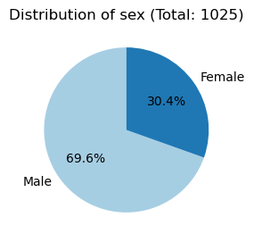

```
*=== Column: chest_pain_type ===*

                  Count  Ratio (%)
chest_pain_type
Typical angina      497       4.85
Non-anginal pain    284       2.77
Atypical angina     167       1.63
Asymptomatic         77       0.75
------------------------------------------------------------
```

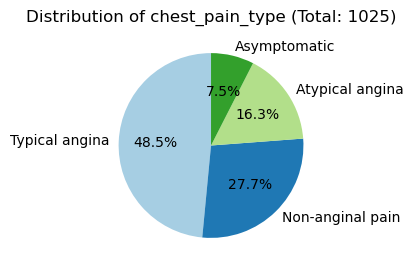

```
*=== Column: fasting_blood_sugar ===*

                        Count  Ratio (%)
fasting_blood_sugar
Lower than 120 mg/ml      872       8.51
Greater than 120 mg/ml    153       1.49
------------------------------------------------------------
```

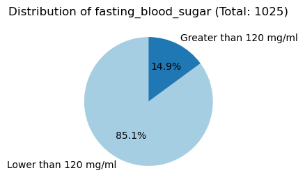

```
*=== Column: rest_ecg ===*

                              Count  Ratio (%)
rest_ecg
ST-T wave abnormality           513       5.00
Normal                          497       4.85
Left ventricular hypertrophy     15       0.15
------------------------------------------------------------
```

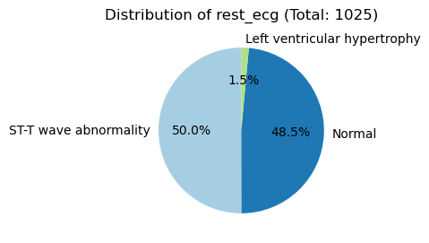

```
*=== Column: exercise_induced_angina ===*

                         Count  Ratio (%)
exercise_induced_angina
No                         680       6.63
Yes                        345       3.37
------------------------------------------------------------
```

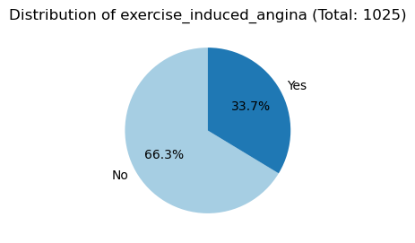

```
*=== Column: slope ===*

             Count  Ratio (%)
slope
Flat           482       4.70
Downsloping    469       4.58
Upsloping       74       0.72
------------------------------------------------------------
```

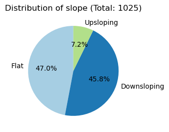

```
*=== Column: vessels_colored_by_flourosopy ===*

                               Count  Ratio (%)
vessels_colored_by_flourosopy
Zero                             578       5.64
One                              226       2.20
Two                              134       1.31
Three                             69       0.67
Four                              18       0.18
------------------------------------------------------------
```

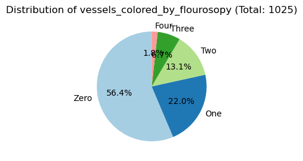

```
*=== Column: thalassemia ===*

                   Count  Ratio (%)
thalassemia
Fixed Defect         544       5.31
Reversable Defect    410       4.00
Normal                64       0.62
No                     7       0.07
------------------------------------------------------------
```

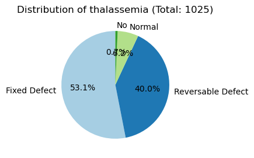

```python
# Observation of class attrivutes.
# Total count for each feature and ratio of each classes within the feature.
for col in class_columns.columns:
    print(f"\n*=== Column: {col} ===*\n")
    summary = (class_columns[col].value_counts().to_frame("Count"))
    summary["Ratio (%)"] = (class_columns[col].value_counts(normalize=True) * 10).round(2)
    print(summary)
    print("-" * 60)


    plt.figure(figsize=(5,3))
    summary["Count"].plot(kind="pie", autopct='%1.1f%%', startangle=90, colors=plt.cm.Paired.colors,legend=False)
    plt.title(f"Distribution of {col} (Total: {len(class_columns[col])})")
    plt.ylabel("")  # removes 'count' from y-axis
    plt.show()
```

### Histogram

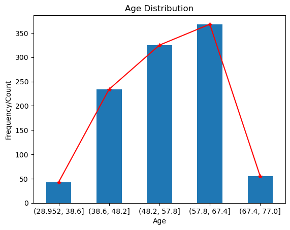

```python
# histogram for age column:


# Divided the age column into five subcategories, each approximately 10 years
df.age.groupby(pd.cut(df.age, 5)).count().plot(kind="bar")
# Line plot as kernel density estimation of the histogram
df.age.groupby(pd.cut(df.age, 5)).count().plot(kind="line",color="red",marker="*")
plt.tick_params(labelrotation=0)
plt.title("Age Distribution")
plt.xlabel("Age")
plt.ylabel("Frequency/Count")
plt.show()
```

- The biggest group, with over 350 people, falls into the 57-67 age bracket.
- The next largest group, with 300 to 350 people, is in the 48-57 age group.
- he third largest, with 200 to 250 people, is the 39-48 age group.
- Interestingly, the youngest and oldest age categories are the smallest groups in the dataset.

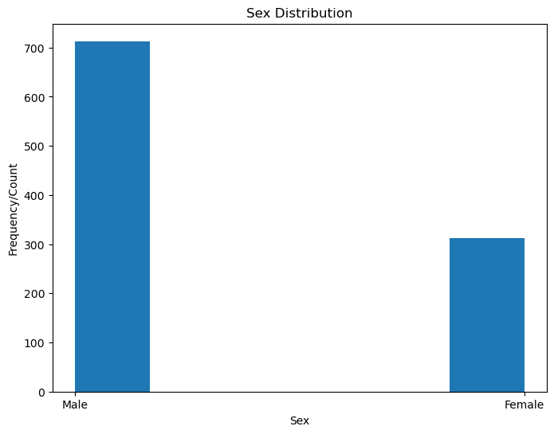

```python
# Histogram for Sex colummn:

plt.figure(figsize=(8, 6))
plt.hist(df['sex'],bins=6)
plt.title('Sex Distribution')
plt.xlabel('Sex')
plt.ylabel("Frequency/Count")
plt.show()
```

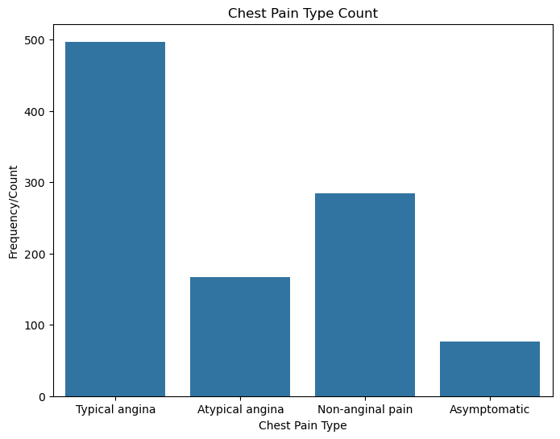

```python
# histogram for chest_pain_type

plt.figure(figsize=(8, 6))
sns.countplot(data=df, x='chest_pain_type')
plt.title('Chest Pain Type Count')
plt.xlabel('Chest Pain Type')
plt.ylabel('Frequency/Count')
plt.show()
```

- Looking at the data, the most common type of chest pain is Typical Angina, affecting almost half of the people (nearly 50%). It's followed by non-anginal pain at around 30%, then Atypical Angina, and finally, asymptomatic is the least common

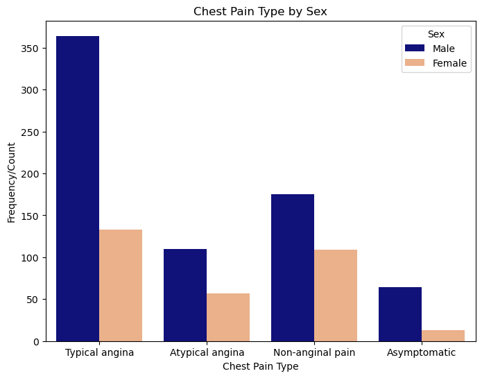

```python
plt.figure(figsize=(8, 6))
sns.countplot(data=df, x='chest_pain_type', hue='sex',palette=["darkblue", "#FAAE7B"])
plt.title('Chest Pain Type by Sex')
plt.xlabel('Chest Pain Type')
plt.ylabel('Frequency/Count')
plt.legend(title='Sex', labels=['Male', 'Female'])
plt.show()
```

- Looking at the data, most of the people who suffer from any type of chest pain are men.
- When it comes to Typical Angina, men are more than twice as likely as women to experience it.
- Interestingly, the types of chest pain men and women experience follow the same overall pattern.

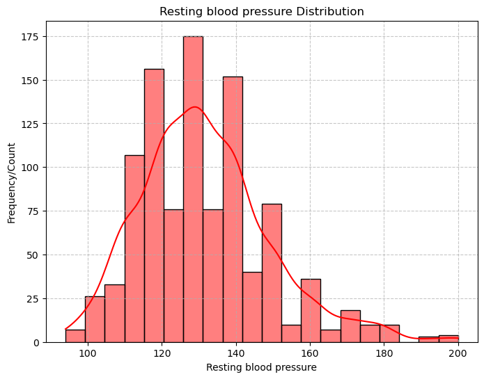

```python
# histogram for Resting blood pressure

plt.figure(figsize=(8,6))
sns.histplot(data=df,x='resting_blood_pressure',kde=True,color='red',bins=20)
plt.grid(True, linestyle='--', alpha=0.7)
plt.title('Resting blood pressure Distribution')
plt.xlabel('Resting blood pressure')
plt.ylabel('Frequency/Count')
plt.show()
```

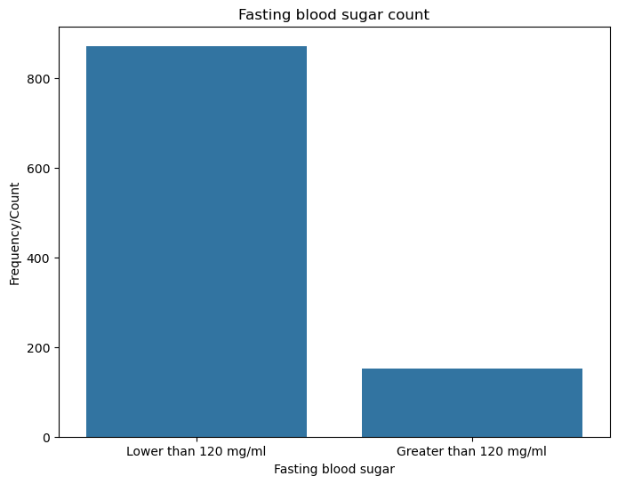

```python
plt.figure(figsize=(8, 6))
sns.countplot(data=df, x='fasting_blood_sugar')
plt.title('Fasting blood sugar count')
plt.xlabel('Fasting blood sugar')
plt.ylabel('Frequency/Count')
plt.show()
```

- The dataset shows that fasting blood sugar is divided into two categories: "lower than 120 mg/ml" and "greater than 120 mg/ml." The majority of the population falls into the "lower than 120 mg/ml" category. This is expected, as fasting typically has a positive impact on blood pressure(https://www.jeffersonhealth.org/your-health/living-well/intermittent-fasting-and-insulin-resistance-benefits-beyond-weight-loss#:~:text=Fasting%20for%20at%20least%2016,space%2Dline).

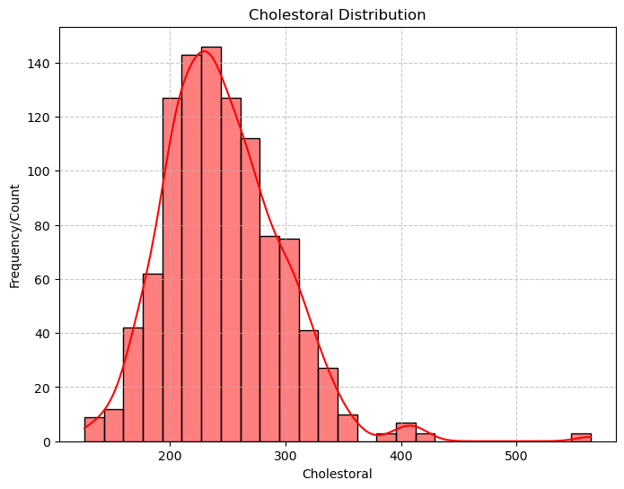

```python
# histogram for cholestoral

plt.figure(figsize=(8,6))
sns.histplot(data=df,x='cholestoral',kde=True,color='red',bins=26)
plt.grid(True, linestyle='--', alpha=0.7)
plt.title('Cholestoral Distribution')
plt.xlabel('Cholestoral')
plt.ylabel('Frequency/Count')
plt.show()
```

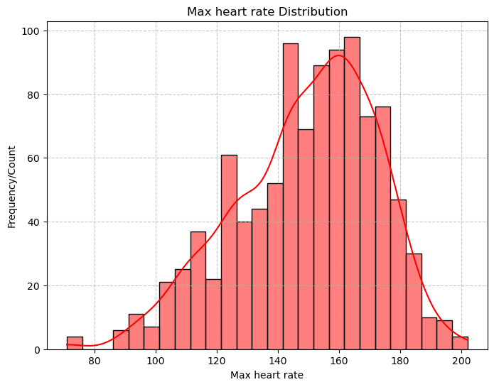

```python
# histogram for Max heart rate distribution

plt.figure(figsize=(8,6))
sns.histplot(data=df,x='Max_heart_rate',kde=True,color='red',bins=26)
plt.grid(True, linestyle='--', alpha=0.7)
plt.title('Max heart rate Distribution')
plt.xlabel('Max heart rate')
plt.ylabel('Frequency/Count')
plt.show()
```

- The distribution of maximum heart rates in this population is skewed to the left, meaning that most people have heart rates clustered at the higher end of the range.
- The most frequent maximum heart rate observed falls within the 140-180 range.
- The data shows a left-skewed distribution for maximum heart rate. The highest concentration of readings is between 140 and 180.

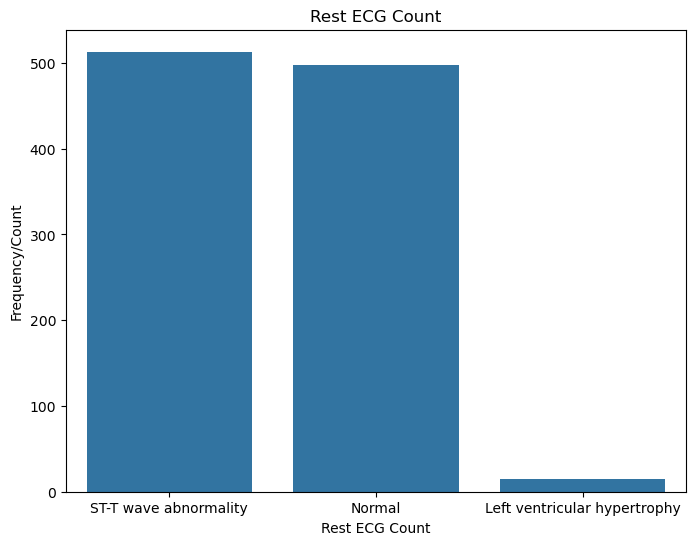

```python
plt.figure(figsize=(8, 6))
sns.countplot(data=df, x='rest_ecg')
plt.title('Rest ECG Count')
plt.xlabel('Rest ECG Count')
plt.ylabel('Frequency/Count')
plt.show()
```

- The Resting ECG results fall into three categories: 'ST-T wave abnormality,' 'Normal,' and 'Left ventricular hypertrophy'.
- It seems the number of people with 'ST-T wave abnormality' is about the same as those with a 'Normal' result, but the frequency of 'Left ventricular hypertrophy' is much lower.

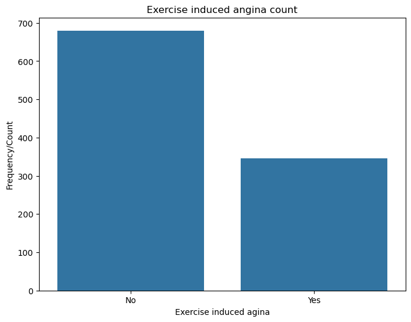

```python
plt.figure(figsize=(8, 6))
sns.countplot(data=df, x='exercise_induced_angina')
plt.title('Exercise induced angina count')
plt.xlabel('Exercise induced agina')
plt.ylabel('Frequency/Count')
plt.show()
```

- Exercise-induced angina is chest pain or discomfort brought on by physical activity.
- The data is categorized simply as "yes" or "no."
- Roughly one-third of the population reports experiencing this pain.

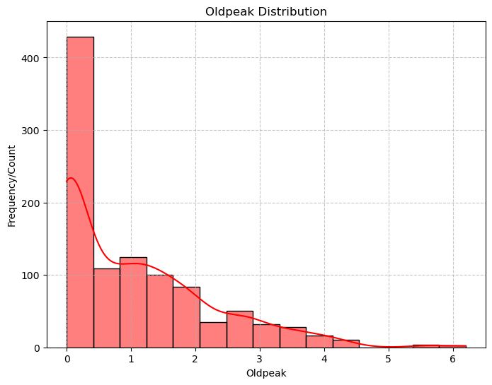

```python
# histogram for oldpeak


plt.figure(figsize=(8,6))
sns.histplot(data=df,x='oldpeak',kde=True,color='red',bins=15)
plt.grid(True, linestyle='--', alpha=0.7)
plt.title('Oldpeak Distribution')
plt.xlabel('Oldpeak')
plt.ylabel('Frequency/Count')
plt.show()
```

- Oldpeak measures the ST segment depression seen on an ECG after exercise compared to at rest.
- The Oldpeak distribution shows a right-skewed distribution.
- The majority of the counts fall within the 0-1 range, compared to all other ranges

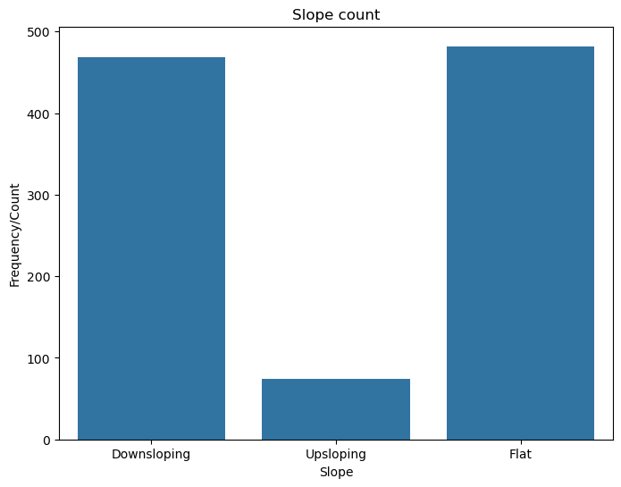

```python
plt.figure(figsize=(8, 6))
sns.countplot(data=df, x='slope')
plt.title('Slope count')
plt.xlabel('Slope')
plt.ylabel('Frequency/Count')
plt.show()
```

- The Slope column has three categories: "Downsloping," "Upsloping," and "Flat."
- The "Flat" and "Downsloping" categories have the majority of the counts and are approximately equal, while "Upsloping" has the lowest count compared to the other two.

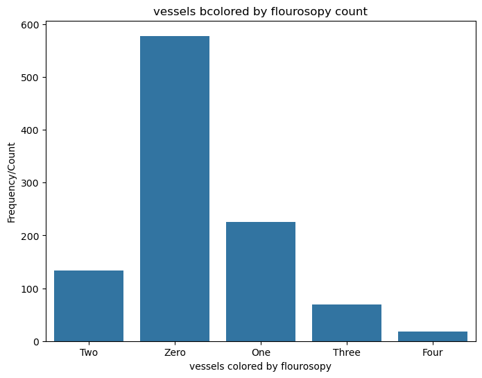

```python
plt.figure(figsize=(8, 6))
sns.countplot(data=df, x='vessels_colored_by_flourosopy')
plt.title('vessels bcolored by flourosopy count')
plt.xlabel('vessels colored by flourosopy')
plt.ylabel('Frequency/Count')
plt.show()
```

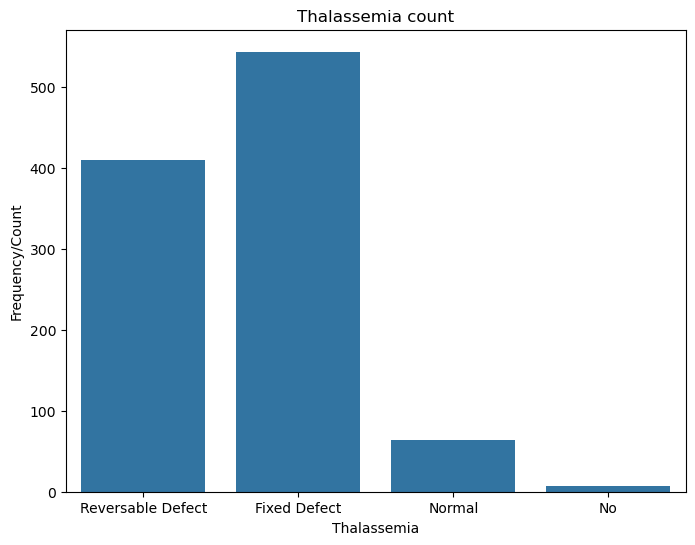

```python
plt.figure(figsize=(8, 6))
sns.countplot(data=df, x='thalassemia')
plt.title('Thalassemia count')
plt.xlabel('Thalassemia')
plt.ylabel('Frequency/Count')
plt.show()
```